# Least Squared Regression with Matrix Algebra

### Representation of linear Models

- The general forumula for a linear model is $Y_i = \beta_0 + \beta_1 x_{1i} + ... + \beta_j x_{ji}+ \varepsilon$
  - $Y_i$ is each actual data point to be fit in the model
  - $\beta_0$ is the a constant, base value from which all data is relative to (graphically it is the intercept)
  - $x_{ji}$ is each variable to be included in the model
    - Each $i$ corresponds to one value in data $Y$, $1,...,N$
    - Each $j$ corresponds to on variable in the model, the number of variables depending on the models design, $1,..,M$
  - $\beta_j$ is the co-variate or coefficient modifying each variable to result in the fit of the model
  - $\varepsilon$ is the residual difference between the model and each individual data point
- In matrix notation:
  $$\left(\begin{array}{c}Y_1\\Y_2\\\vdots\\Y_N\end{array}\right) = \left(\begin{array}{cccc}1 & x_{1,1} & x_{1,2} & x_{1,...} & x_{1,M}\\1 & x_{2,1} & x_{2,2} & x_{2,...} & x_{2,M}\\\vdots & \vdots & \vdots & \vdots & \vdots\\1 & x_{N,1} & x_{N,2} & x_{N,...} & x_{N,M}\end{array}\right)\left(\begin{array}{c}\beta_0\\\beta_1\\\beta_2\\\vdots\\\beta_M\end{array}\right) + \left(\begin{array}{c}\varepsilon_1\\\varepsilon_2\\\vdots\\\varepsilon_N\end{array}\right)$$
  - $Y_1,..,Y_N$ represents each point of data
  - The first column of 1s in the $x$ matrix is there because values in that column will always be matrix multiplied by the value of $\beta_0$. Since $\beta_0$ is a constant, it should not change according to any data.
  - Each remaining column in the $X$ matrix represents a variable of interest in the model from 1 to $M$
    - $X$ is often refered to as the **design matrix** particular when applied to categorical variables
  - Each row in the $X$ matrix represents the variables applied to each point of data, 1 through $N$, in $Y$
  - The one column $\beta$ matrix is what is to be calculated by the linear model
  - When completed, each “row” of the model will completely calculate each point in $Y$
- Model can be more simply denoted by:
  $$Y = X\beta + \varepsilon$$

### Solving linear models by least squares

- The least squares regression is the model that minimizes the square of the residuals (i.e. the difference between an actual value and the expected value based on the model, at the same point)
- The sum of squares can ordinarly be writted as $\sum_{i=1}^N R_i^2$, where $R$ is the residual
- In matrix notation this would be represented as $(Y-X\beta)^T(Y-X\beta)$
  - $X\beta$ represents the dot product of all variables and their co-variates for each data point, thus representing a vector of all expected values
  - $Y$ represents the vector of all actual values
  - Therefore $(Y-X\beta)$ is the vector of all residuals
  - Finally, recall the crossproduct of a single matrix is the way to obtain the square of that matrix
- The first derivative of an equation allows us to determine minimums (and maximums) based on where the derivative is equal to zero
  - The derivative of the matrix-form residual equation equal to zero (to find the minumum) is $2X^T(Y-X\hat{\beta}) = 0$
    - Formula is similar to the derivative of $f(x)^2$ being $2f(x)f\prime(x)$
    - $\hat{\beta}$ because $\beta$ is being calculated
  - Solving for zero results in $2X^T(Y-X\hat{\beta})\Rightarrow X^TX\hat{\beta} = X^TY \Rightarrow \hat{\beta} = (X^TX)^{-1}X^TY$
    - Remember that dividing by a matrix requires instead multiplying by that matrix’s inverse (see last step)
    - Notice that the final equation contains a two cross products
- **Thus, the equation to solve a linear model is:**
  $$\hat{\beta} = (X^TX)^{-1}X^TY$$

### Basic linear regression

- Finding the regression line between father vs. son height

  ```r
  library(UsingR)
  head(father.son)
  ```

  ```
  ##    fheight  sheight
  ## 1 65.04851 59.77827
  ## 2 63.25094 63.21404
  ## 3 64.95532 63.34242
  ## 4 65.75250 62.79238
  ## 5 61.13723 64.28113
  ## 6 63.02254 64.24221
  ```

- Set up $X$ (design matrix)

  ```r
  x=father.son$fheight
  y=father.son$sheight
  X <- cbind(1,x)
  head(X)
  ```

  ```
  ##               x
  ## [1,] 1 65.04851
  ## [2,] 1 63.25094
  ## [3,] 1 64.95532
  ## [4,] 1 65.75250
  ## [5,] 1 61.13723
  ## [6,] 1 63.02254
  ```

- Calculating the model coefficients

  ```r
  beta <- solve(t(X)%*%X)%*%t(X)%*%y
  ###or, because of the cross products
  beta <- solve(crossprod(X))%*%crossprod(X,y)
  beta
  ```

  ```
  ##        [,1]
  ##   33.886604
  ## x  0.514093
  ```

- These are the same coefficients calculated by the `lm` function in R

  ```r
  fit <- lm(y ~ x)
  summary(fit)$coefficients
  ```

  ```
  ##              Estimate Std. Error  t value     Pr(>|t|)
  ## (Intercept) 33.886604 1.83235382 18.49348 1.604044e-66
  ## x            0.514093 0.02704874 19.00618 1.121268e-69
  ```

- Thus, the least square line is $f(x) = 33.89 + 0.51x$, which looks like:

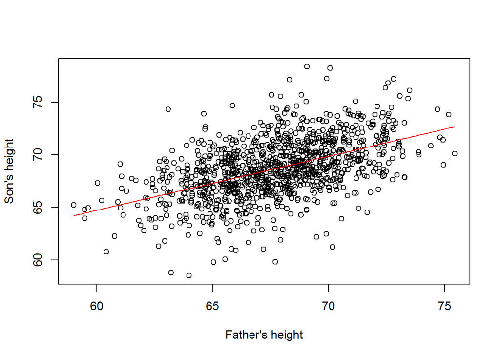

- The effect of multiple variables can be used model the outcome of a single dependent variable using linear models
- Can we model `mpg` (miles per gallon) of cars with `wt` (weight) and `hp` (horsepower) from the `mtcars` dataset?

  ```r
  head(mtcars)
  ```

  ```
  ##                    mpg cyl disp  hp drat    wt  qsec vs am gear carb
  ## Mazda RX4         21.0   6  160 110 3.90 2.620 16.46  0  1    4    4
  ## Mazda RX4 Wag     21.0   6  160 110 3.90 2.875 17.02  0  1    4    4
  ## Datsun 710        22.8   4  108  93 3.85 2.320 18.61  1  1    4    1
  ## Hornet 4 Drive    21.4   6  258 110 3.08 3.215 19.44  1  0    3    1
  ## Hornet Sportabout 18.7   8  360 175 3.15 3.440 17.02  0  0    3    2
  ## Valiant           18.1   6  225 105 2.76 3.460 20.22  1  0    3    1
  ```

- Both `wt` and `hp` seem to correlate with `mp`

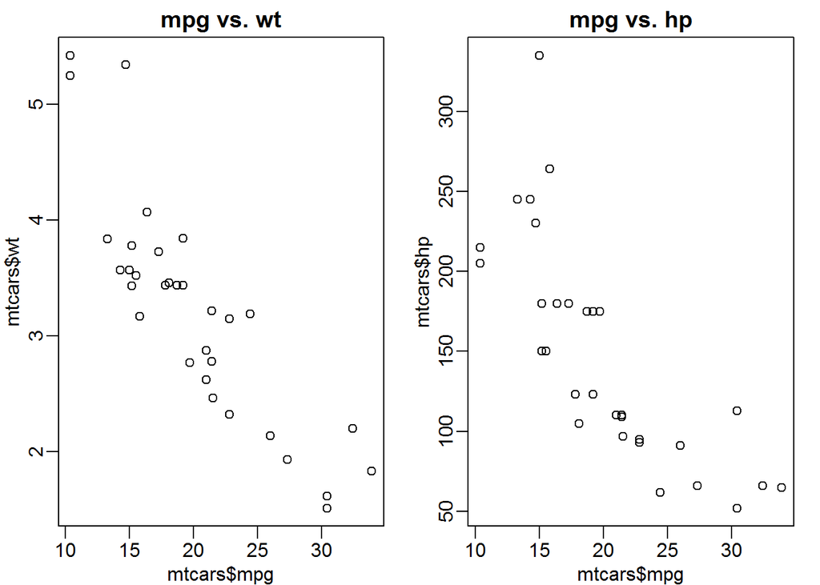

  ```r
  library(rafalib)
  mypar(1,2)
  plot(mtcars$mpg, mtcars$wt, main="mpg vs. wt")
  plot(mtcars$mpg, mtcars$hp, main="mpg vs. hp")
  ```

- Set up $X$ (design matrix)
  - The columns will correspond to the `intercept`, `wt`, then `hp`

  ```r
  Y <- mtcars$mpg
  X <- cbind(1,mtcars$wt,mtcars$hp)
  head(X)
  ```

  ```
  ##      [,1]  [,2] [,3]
  ## [1,]    1 2.620  110
  ## [2,]    1 2.875  110
  ## [3,]    1 2.320   93
  ## [4,]    1 3.215  110
  ## [5,]    1 3.440  175
  ## [6,]    1 3.460  105
  ```

- Calculating the model coefficients

  ```r
  beta <- solve(crossprod(X))%*%crossprod(X,Y)
  beta
  ```

  ```
  ##             [,1]
  ## [1,] 37.22727012
  ## [2,] -3.87783074
  ## [3,] -0.03177295
  ```

- Again, note that the calculated coefficients match those derived from `lm`

  ```r
  fit <- lm(mtcars$mpg ~ mtcars$wt + mtcars$hp)
  summary(fit)$coefficients
  ```

  ```
  ##                Estimate Std. Error   t value     Pr(>|t|)
  ## (Intercept) 37.22727012 1.59878754 23.284689 2.565459e-20
  ## mtcars$wt   -3.87783074 0.63273349 -6.128695 1.119647e-06
  ## mtcars$hp   -0.03177295 0.00902971 -3.518712 1.451229e-03
  ```

### Multiple regression with categorical variables

**Unique considerations of categorical values**

- In order to be used in regression calculations, categorical variables have to be converted in to integer equivalents, often called **dummy variables**
- Dummy variables only take the values of `0` or `1`
  - `0` is always used to code whatever is chosen to be the reference level of that variable
  - For a two-level categorical variable, the remaining level is coded as `1`
- Variables with more than two factor levels are split into multiple dummy variables
  - `0` is always the same reference level for all associated dummy variables
  - E.g. for variable size = {small, medium, large}, with reference level small, there would be two dummy variables
    - `sizeMedium` - `0` = small, `1` = medium
    - `sizeLarge` - `0` = small, `1` = large

**The `warpbreaks` example**

- The `warpbreaks` data set measures the number of breaks in a length of wool based on the type of wool (A or B) and tension (low, medium, high)
- Can we model the number of breaks based on these two types of categorical variables?

  ```r
  library(multcomp)
  data("warpbreaks")
  head(warpbreaks)
  ```

  ```
  ##   breaks wool tension
  ## 1     26    A       L
  ## 2     30    A       L
  ## 3     54    A       L
  ## 4     25    A       L
  ## 5     70    A       L
  ## 6     52    A       L
  ```

- At least one variable appears correlated with number of breaks

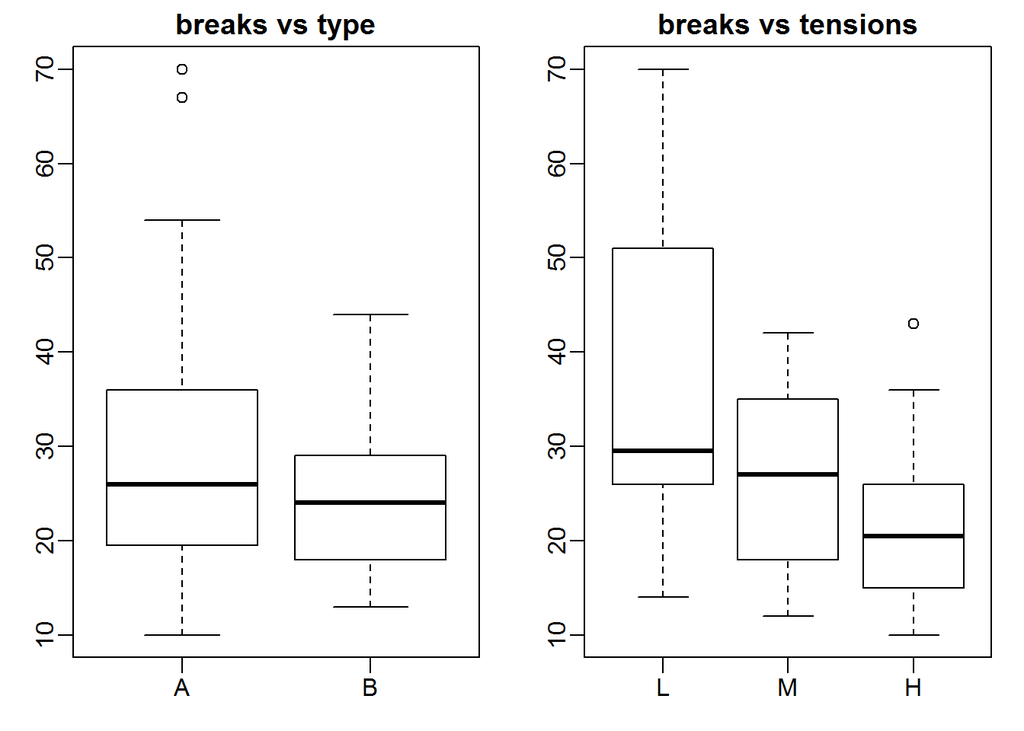

  ```r
  library(rafalib)
  mypar(1,2)
  boxplot(breaks ~ wool, warpbreaks, main="breaks vs type")
  boxplot(breaks ~ tension, warpbreaks, main="breaks vs tensions")
  ```

- Set up $X$ (design matrix)
  - Notice how the 3-level `tension` variable is split into 2 dummy variables

  ```r
  Y <- warpbreaks$breaks
  X <- model.matrix(~warpbreaks$wool + warpbreaks$tension)
  head(X,20)
  ```

  ```
  ##    (Intercept) warpbreaks$woolB warpbreaks$tensionM warpbreaks$tensionH
  ## 1            1                0                   0                   0
  ## 2            1                0                   0                   0
  ## 3            1                0                   0                   0
  ## 4            1                0                   0                   0
  ## 5            1                0                   0                   0
  ## 6            1                0                   0                   0
  ## 7            1                0                   0                   0
  ## 8            1                0                   0                   0
  ## 9            1                0                   0                   0
  ## 10           1                0                   1                   0
  ## 11           1                0                   1                   0
  ## 12           1                0                   1                   0
  ## 13           1                0                   1                   0
  ## 14           1                0                   1                   0
  ## 15           1                0                   1                   0
  ## 16           1                0                   1                   0
  ## 17           1                0                   1                   0
  ## 18           1                0                   1                   0
  ## 19           1                0                   0                   1
  ## 20           1                0                   0                   1
  ```

- `imagemat` in `rafalib` is a convenient way to view the entire design matrix of a model with only categorical variables
  - Rows and columns correspond to the same rows (data points) and columns (dummy variables) in the design matrix above
  - `0` = White
  - `1` = Black

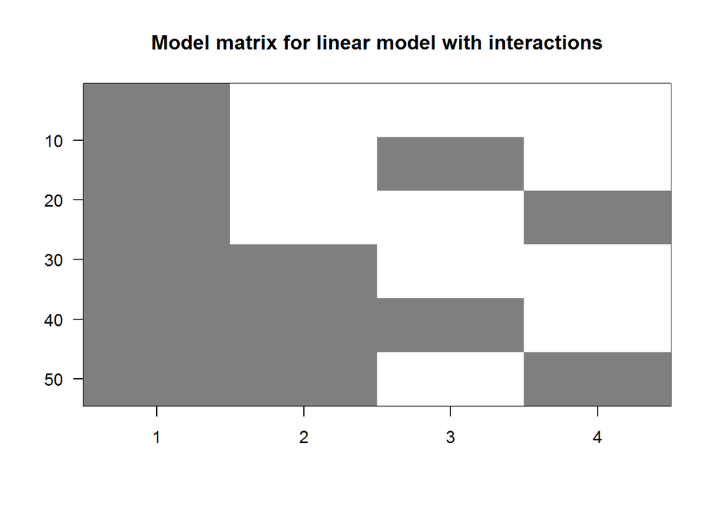

  ```r
  library(rafalib)
  imagemat(X, main="Model matrix for linear model with interactions")
  ```

- Calculating the model coefficients

  ```r
  beta <- solve(crossprod(X))%*%crossprod(X,Y)
  beta
  ```

  ```
  ##                           [,1]
  ## (Intercept)          39.277778
  ## warpbreaks$woolB     -5.777778
  ## warpbreaks$tensionM -10.000000
  ## warpbreaks$tensionH -14.722222
  ```

- Again, note that the calculated coefficients match those derived from `lm`

  ```r
  fit <- lm(breaks ~ wool + tension, data = warpbreaks)
  summary(fit)$coefficients
  ```

  ```
  ##               Estimate Std. Error   t value     Pr(>|t|)
  ## (Intercept)  39.277778   3.161783 12.422667 6.681866e-17
  ## woolB        -5.777778   3.161783 -1.827380 7.361367e-02
  ## tensionM    -10.000000   3.872378 -2.582393 1.278683e-02
  ## tensionH    -14.722222   3.872378 -3.801856 3.913842e-04
  ```